# Setting Up R

DPI R Bootcamp Dec. 3rd to 5th, 2012

Jared Knowles

# Getting Ready for the DPI R Bootcamp

- How to get up and running with R in no time!

# Materials

- [Download R](http://cran.r-project.org/)
- [RStudio](http://www.rstudio.org/)
- We'll also want to install a few basic packages. This can be done on the fly later, but a few include `ggplot2`;`knitr`;`plyr`

# Step 1: Install R

- Simply run the installer. If you have a 64-bit machine, choose 64 bit R, if you don't know, just choose the default
- The install should be less than 100mb
- There is a short video on the next slide for help installing on Windows machines

# Installing R on Windows

[interactive chart not shown]

# Installing R on a Mac

- Get the install file from [CRAN](http://cran.r-project.org/bin/macosx/)
- Get [RStudio](http://www.rstudio.org/)
- Run the R installer, and then run the RStudio installer

# Installing R on Ubuntu or Debian Linux

- Read the [install notes online](http://cran.r-project.org/bin/linux/ubuntu/README)
- Get [RStudio](http://www.rstudio.org/)
- Run the R installer, and then run the RStudio installer

# Step 2: RStudio

- Now run the RStudio installer
- RStudio will automatically find your R installation

# Step 3: Install packages

First, watch this tutorial

[interactive chart not shown]

# Install Packages

- Are you running RStudio in administrator mode on Windows Vista or Windows 7?
- If not, you need to be to install packages (in most cases)
- When you launch RStudio, right click on the icon for RStudio and then click "Run as Administrator"
- If you are on a Mac or Windows XP you can disregard this

# Install Packages (2)

- Now, copy and paste the code below into the bottom left window in RStudio (the R terminal):

```r
install_new<-function(mypkg){
  if (mypkg %in% installed.packages()) cat("Package already installed")
  else{cat("Package not found, so installing with dependencies...\n
           Press CTRL C to abort.")
    Sys.sleep(5)
    install.packages(mypkg,repos="http://cran.wustl.edu/")
}
}

install_new('plyr')
install_new('lmtest')
install_new('ggplot2')
install_new('gridExtra')
install_new('eeptools')
install_new('stringr')
install_new('knitr')
install_new('quantreg')
install_new('xtable')
install_new('lme4')
install_new('caret')
```

# Alternate Install

- If you want or if you have troubles with the above, you can overwrite any existing versions of those packages and do the install in one line, shown below:

```r
install.packages(c('plyr','lmtest','ggplot2','gridExtra','stringr',
                   'knitr','quantreg','xtable','lme4','eeptools','caret'),
                 repos="http://cran.wustl.edu/")
```

# Run RStudio

- You should be able to run RStudio now and load any of the packages above.
- Run the code below in the RStudio terminal panel (bottom left) to test this:

```r
library(lmtest)
example(gqtest)
```

# And you should see...

```
## as.Date, as.Date.numeric
```

```
##
## gqtest> ## generate a regressor
## gqtest> x <- rep(c(-1,1), 50)
##
## gqtest> ## generate heteroskedastic and homoskedastic disturbances
## gqtest> err1 <- c(rnorm(50, sd=1), rnorm(50, sd=2))
##
## gqtest> err2 <- rnorm(100)
##
## gqtest> ## generate a linear relationship
## gqtest> y1 <- 1 + x + err1
##
## gqtest> y2 <- 1 + x + err2
##
## gqtest> ## perform Goldfeld-Quandt test
## gqtest> gqtest(y1 ~ x)
##
##  Goldfeld-Quandt test
##
## data:  y1 ~ x
## GQ = 2.937, df1 = 48, df2 = 48, p-value = 0.0001425
##
##
## gqtest> gqtest(y2 ~ x)
##
##  Goldfeld-Quandt test
##
## data:  y2 ~ x
## GQ = 1.389, df1 = 48, df2 = 48, p-value = 0.1293
```

# And test the graphics...

Type in in the terminal (or copy and paste)

```r
library(ggplot2)
y <- rt(200, df = 5)
qplot(sample = y, stat = "qq")
```

# Results

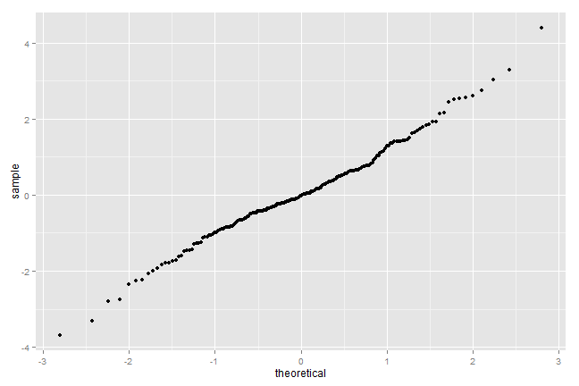

```r
library(ggplot2)
y <- rt(200, df = 5)
qplot(sample = y, stat = "qq")
```

# That's all

- Did you see the output like the slides above?
- Did you see the plot in the lower right?

# Optional

- If you want to see the cutting edge of R development--interactive web-based data applications, you can install the following beta software

```r
options(repos = c(RStudio = "http://rstudio.org/_packages", getOption("repos")))
install.packages("shiny")
```

# Optional Cont.

- To check if it worked (and it might not depending on your machine's configuration)

```r
library(shiny)
runExample("06_tabsets")
```

- Does a new browser window or tab open up?
- In RStudio hit the "stop" button in the terminal panel to exit the demo

# You are ready to go!

See you on December 3rd to the 5th to find out how to go from these basic steps to using R to learn from your data.

Can't wait to see you in Madison!

# Attribution and License

This work (R Tutorial for Education, by Jared E. Knowles), in service of the [Wisconsin Department of Public Instruction](http://www.dpi.wi.gov), is free of known copyright restrictions.